# Tutorial 3

Bethany Glinsmann

3/19/2019

# Today

1. **Intro to plotting in R**
2. **Scatterplots**
3. **Histograms**
4. **Plot aesthetics**
5. **Arranging multiple plots**

## 0. Load required packages and data

```r
# Load packages
library(dplyr)
library(ggplot2)
library(gridExtra)

my_data <- mtcars
glimpse(my_data)
```

```
## Observations: 32
## Variables: 11
## $ mpg  <dbl> 21.0, 21.0, 22.8, 21.4, 18.7, 18.1, 14.3, 24.4, 22.8, 19....
## $ cyl  <dbl> 6, 6, 4, 6, 8, 6, 8, 4, 4, 6, 6, 8, 8, 8, 8, 8, 8, 4, 4, ...
## $ disp <dbl> 160.0, 160.0, 108.0, 258.0, 360.0, 225.0, 360.0, 146.7, 1...
## $ hp   <dbl> 110, 110, 93, 110, 175, 105, 245, 62, 95, 123, 123, 180, ...
## $ drat <dbl> 3.90, 3.90, 3.85, 3.08, 3.15, 2.76, 3.21, 3.69, 3.92, 3.9...
## $ wt   <dbl> 2.620, 2.875, 2.320, 3.215, 3.440, 3.460, 3.570, 3.190, 3...
## $ qsec <dbl> 16.46, 17.02, 18.61, 19.44, 17.02, 20.22, 15.84, 20.00, 2...
## $ vs   <dbl> 0, 0, 1, 1, 0, 1, 0, 1, 1, 1, 1, 0, 0, 0, 0, 0, 0, 1, 1, ...
## $ am   <dbl> 1, 1, 1, 0, 0, 0, 0, 0, 0, 0, 0, 0, 0, 0, 0, 0, 0, 1, 1, ...
## $ gear <dbl> 4, 4, 4, 3, 3, 3, 3, 4, 4, 4, 4, 3, 3, 3, 3, 3, 3, 4, 4, ...
## $ carb <dbl> 4, 4, 1, 1, 2, 1, 4, 2, 2, 4, 4, 3, 3, 3, 4, 4, 4, 1, 2, ...
```

```r
# ?mtcars includes variable definitions
```

## 1. Intro to plotting in base R

Plotting in R can be simple or complicated, depending on your needs. To get started, you could use some basic plotting functions, such as plot() to create a scatterplot or hist() to create a histogram. When using these functions, you first specify your data and variables, and then add additional options related to labels and appearance.

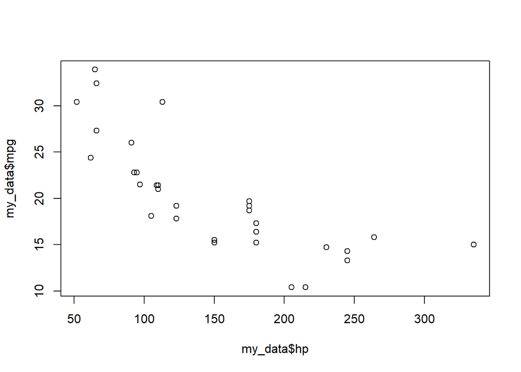

```r
# Basic scatterplot
plot(x = my_data$hp, y = my_data$mpg)
```

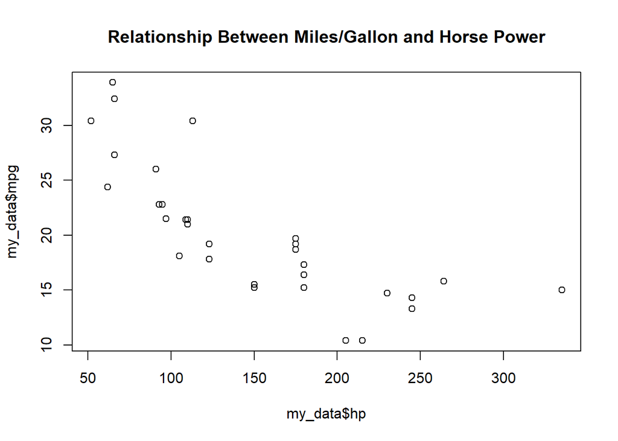

```r
# Add a title
plot(x = my_data$hp, y =my_data$mpg,
     main = "Relationship Between Miles/Gallon and Horse Power")
```

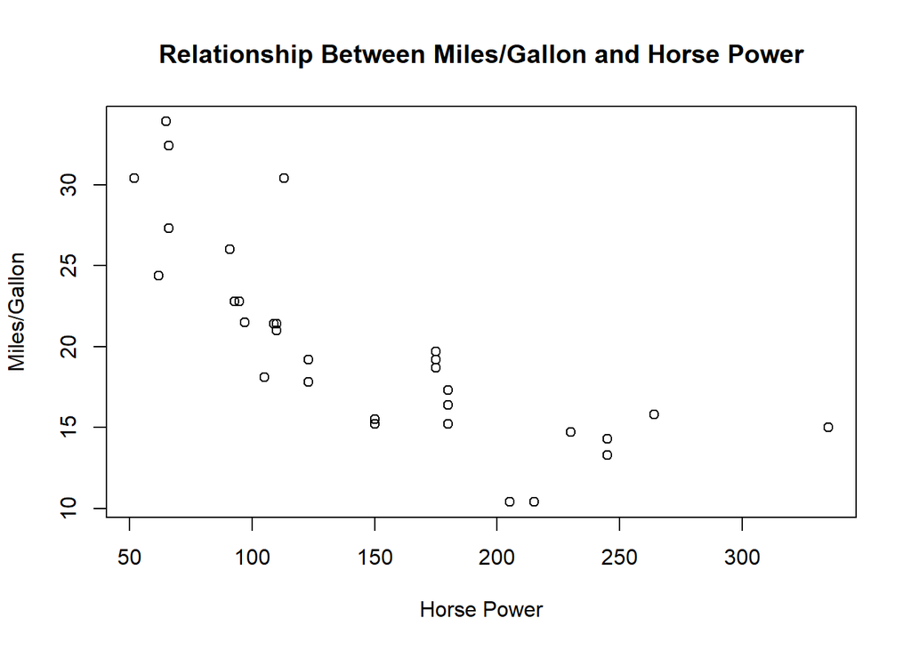

```r
# Change labels of the axes
plot(x = my_data$hp, y =my_data$mpg,
     main = "Relationship Between Miles/Gallon and Horse Power",
     xlab = "Horse Power",
     ylab = "Miles/Gallon")
```

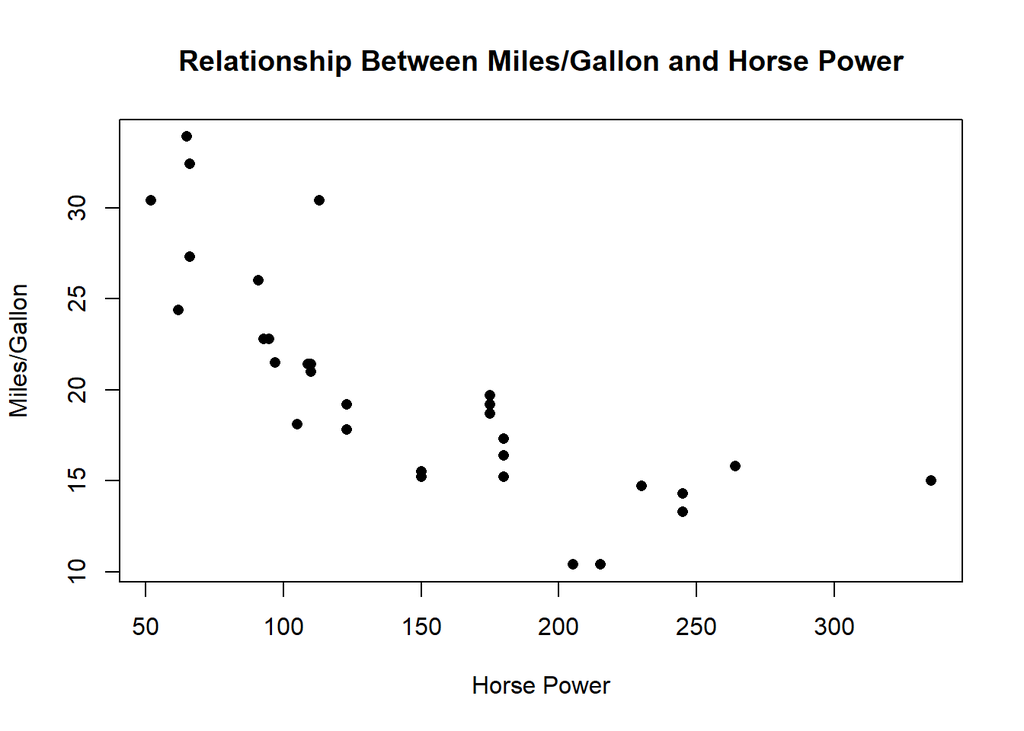

```r
# Change style of point
plot(x = my_data$hp, y =my_data$mpg,
     main = "Relationship Between Miles/Gallon and Horse Power",
     xlab = "Horse Power",
     ylab = "Miles/Gallon",
     pch = 16)
```

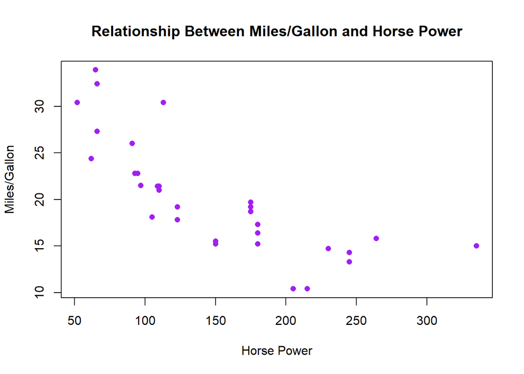

```r
# Change color of plot
plot(x = my_data$hp, y =my_data$mpg,
     main = "Relationship Between Miles/Gallon and Horse Power",
     xlab = "Horse Power",
     ylab = "Miles/Gallon",
     pch = 16,
     col = "purple")
```

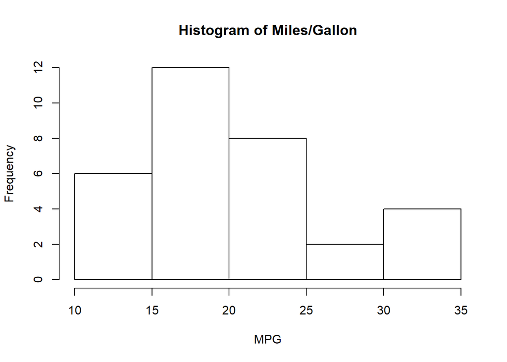

```r
# Basic histogram (with frequency count)
hist(my_data$mpg,
     freq = TRUE,
     main = "Histogram of Miles/Gallon",
     xlab = "MPG")
```

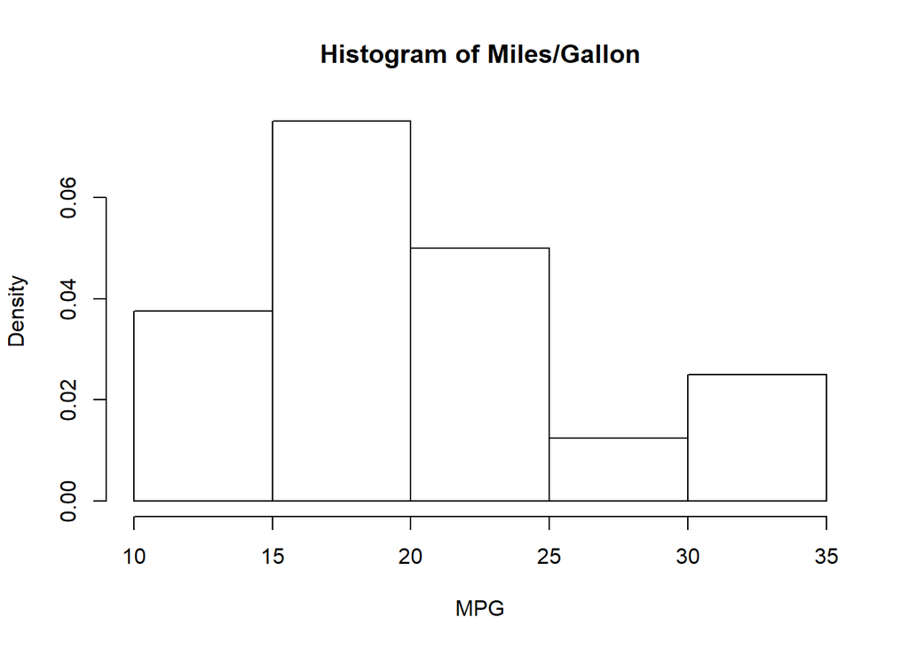

```r
# Basic histogram (with relative frequency)
hist(my_data$mpg,
     freq = FALSE,
     main = "Histogram of Miles/Gallon",
     xlab = "MPG")
```

```r
# Save your plot
# pdf("file_path/plot_name.pdf")
# plot(x = my_data$hp, y = my_data$mpg)
# dev.off()
```

The ggplot2 package is a very powerful tool for creating visually pleasing plots. We will use the ggplot() function going forward. This website is a good resource for learning more: https://ggplot2.tidyverse.org Download their “cheatsheet” for ggplot2.

## 2. Advanced plotting with ggplot: Scatterplots

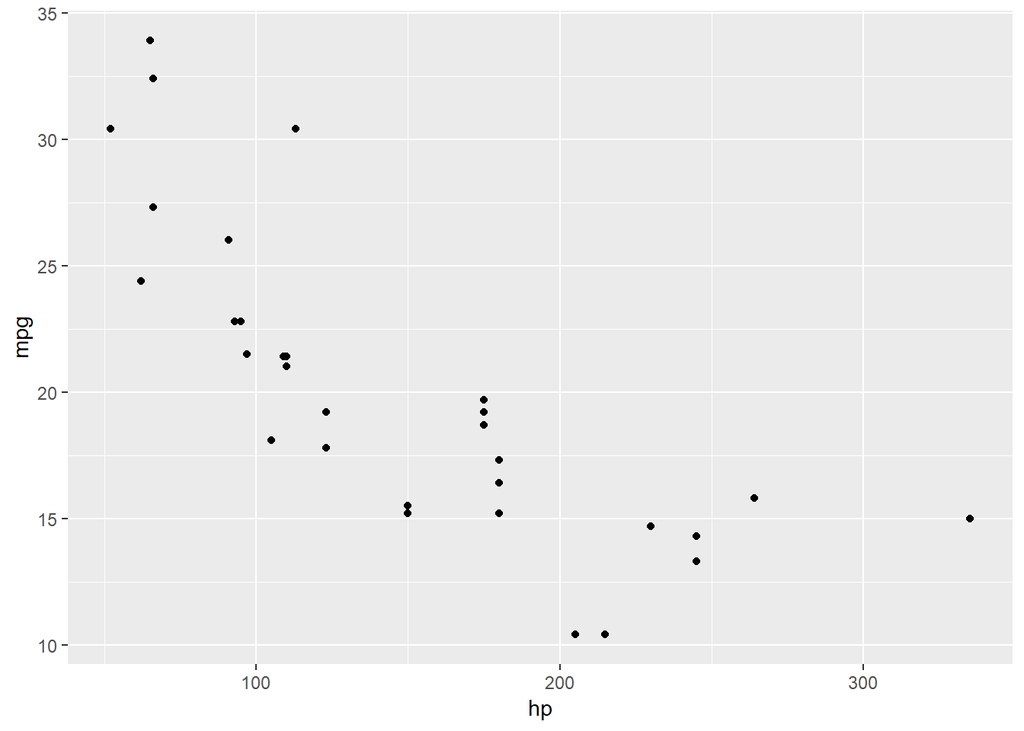

```r
# Basic scatterplot
ggplot(data = my_data, # specify the data
       aes(x = hp, y = mpg)) + # specify the variables (x, y axes)
         geom_point()  # specify how to represent the data points, can add aesthetic options here
```

```r
# Save the plot as an object and add more aethetic layers
plot.mpg.hp <- ggplot(data = my_data,
                      aes(x = hp, y = mpg)) +
                        geom_point(colour = "purple", shape = 18, size = 3) + # Specify color, shape, and size of points
                        ggtitle("Miles/Gallon vs Horse Power") + # Add title
                        ylab("Miles/Gallon") + # Label y-axis
                        xlab("Horse Power") + # Label x-axis
                        theme(title = element_text(size=12, face = 'bold'), # Increase title font size and make bold
                              plot.title = element_text(hjust = 0.5)) # Center title

# Type ?pch in your console to see the corresponding numeric values for different plotting characters.
```

Now play around with changing the color, size, and other aesethetics.

## 3. Advanced plotting with ggplot: Histograms

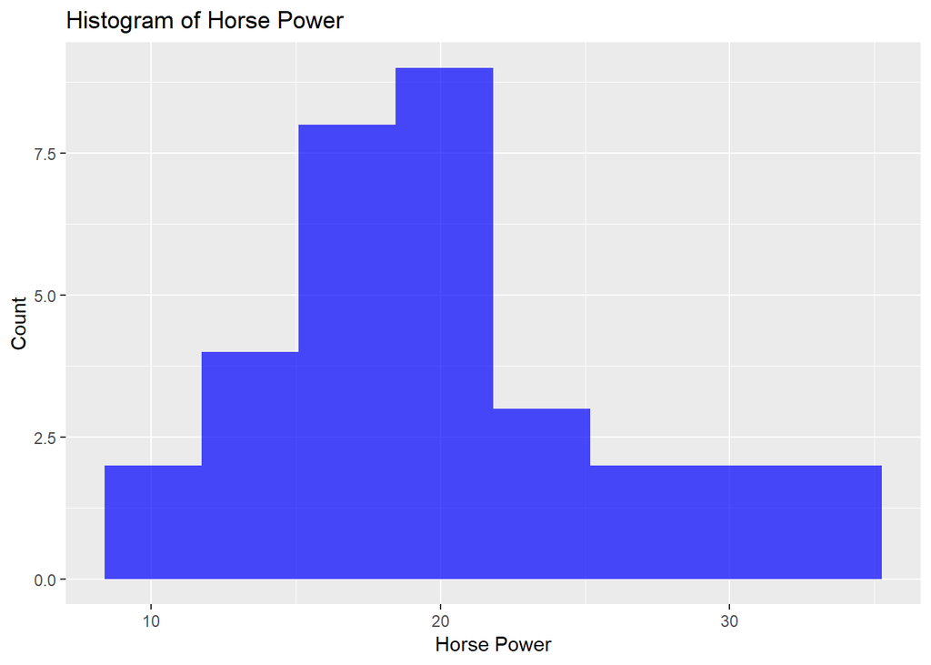

```r
# Basic histogram
ggplot(data = my_data, # specify the data
       aes(mpg)) + # specify the variable of interest
        geom_histogram(bins = 8, fill = "blue", alpha = .7) + # Specify number of bins, color, and transparency
        ggtitle("Histogram of Horse Power") + # Add title
        xlab("Horse Power") + # Label x-axis
        ylab("Count") # Label y-axis
```

```r
# Save the plot as an object
hist.mpg <- ggplot(data = my_data, # specify the data
       aes(mpg)) + # specify the variable of interest
        geom_histogram(bins = 8, fill = "blue", alpha = .7) + # Specify number of bins, color, and transparency
        ggtitle("Histogram of Horse Power") + # Add title
        xlab("Horse Power") + # Label x-axis
        ylab("Count") # Label y-axis

# Export the plot to a PDF
# Note the "~" is a relative file path. It is relative to your R working directory,
# which can be identified using getwd()
ggsave(filename = "~/AAE 770 - math/R_Materials_AAE636_Zhidong/Bethany/mpg-hp.pdf", # Specify location to save file
       hist.mpg, # Specify plot to save
       device = "pdf")
```

## 4. Plot aesthetics

Let’s play around with a few more aethetics. The options are limitless!

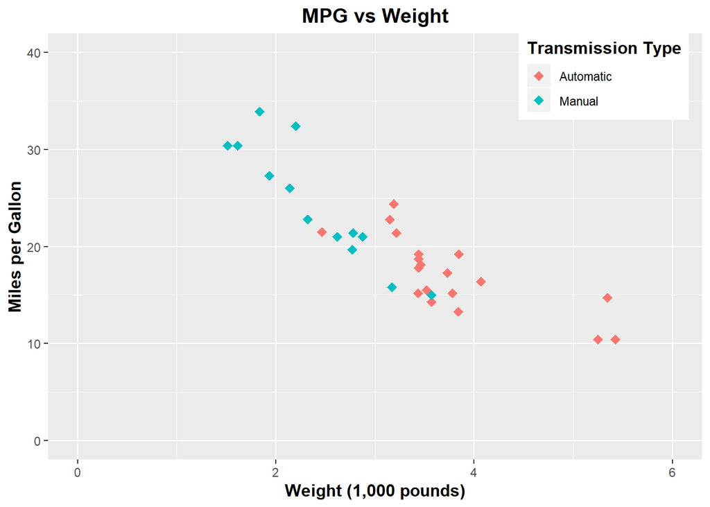

```r
# Scatterplot: MPG vs weight
# Change color of dots based on manual vs. automatic transmission
scatter1 <- ggplot(data = my_data,
                  aes(x = wt, y = mpg,
                      color = factor(am, labels = c("Automatic", "Manual")))) + # factor converts this from a continuous variable to a discrete variable. Also add labels for legend to replace 0/1 values
                    geom_point(shape = 18, size = 3) + # Specify shape and size of points
                    xlim(0,6) + # Specify x-axis range
                    ylim(0,40) + # Specify y-axis range
                    labs(title = "MPG vs Weight", # Add title
                         x = "Weight (1,000 pounds)", # Label x-axis
                         y = "Miles per Gallon", # Label y-axis
                         color = "Transmission Type") + # Legend header
                    theme(title = element_text(size=12, face = 'bold'), # Increase title font size and make bold
                          plot.title = element_text(hjust = 0.5), # Center title
                          legend.position = c(.85, .9)) # Specify legend position

scatter1
```

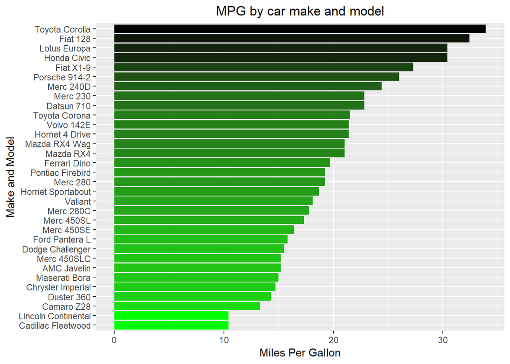

```r
# Bar chart: Miles per gallon

# Start by arranging the data by miles per gallon
my_data_2 <- my_data %>%
  mutate(make_model = rownames(my_data))  # Preserve the car make and model info, which is stored as row names


bar1 <- ggplot(my_data_2,
               aes(x = reorder(make_model, mpg), y = mpg, fill = mpg)) + # Sort by mpg, descending
          geom_bar(stat = "identity") + # Specify the height of bars is equal to the data value
          scale_fill_gradient(low = "green", high = "black") + # Specify bar fill colors
          labs(title = "MPG by car make and model",
               x = "Make and Model",
               y = "Miles Per Gallon") +
          theme(legend.position = "none", # Remove legend
                plot.title = element_text(hjust = 0.5)) + # Center title
          coord_flip() # Transpose the plot for horizontal bars

bar1
```

## 5. Arranging multiple plots

The gridExtra package allows you to place multiple plots in a matrix by specifying the number of columns and/or rows.

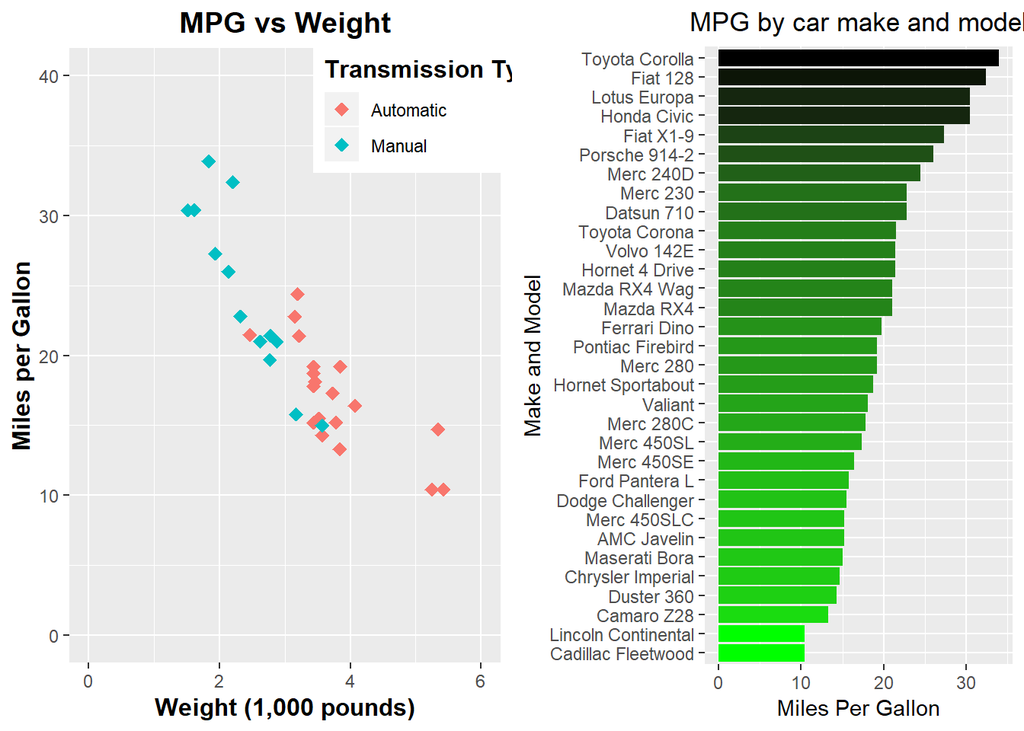

```r
# install.packages("gridExtra")
gridExtra::grid.arrange(scatter1, bar1, ncol=2)
```

The facet_grid() function allows you to plot data in a matrix, based on a discrete variable. Here’s an example using the transmission type.

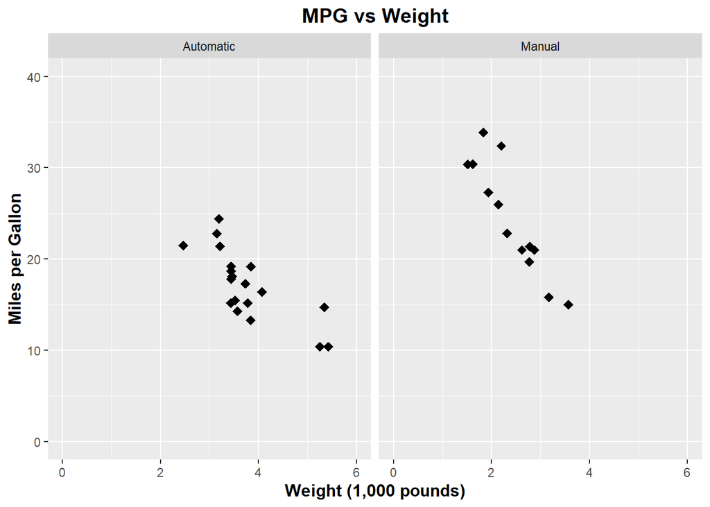

```r
# Scatterplots of MPG vs weight, by transmission type

ggplot(data = my_data,
              aes(x = wt, y = mpg)) +
                geom_point(shape = 18, size = 3) + # Specify shape and size of points
                xlim(0,6) + # Specify x-axis range
                ylim(0,40) + # Specify y-axis range
                labs(title = "MPG vs Weight", # Add title
                     x = "Weight (1,000 pounds)", # Label x-axis
                     y = "Miles per Gallon") + # Label y-axis
                theme(title = element_text(size=12, face = 'bold'), # Increase title font size and make bold
                      plot.title = element_text(hjust = 0.5)) + # Center title
                facet_grid(cols = vars(factor(am, labels = c("Automatic", "Manual")))) # Specify facet variable and manually label
```